# exploration_ford_ride

## Preliminary Wrangling

```python
# import all packages and set plots to be embedded inline
import numpy as np
import pandas as pd
import matplotlib.pyplot as plt
import seaborn as sns

#import geopy
#import folium

%matplotlib inline
```

### Data assessment and cleaning

```python
df = pd.read_csv('201801-fordgobike-tripdata.csv')

df.head()
df.info()
```

```
<class 'pandas.core.frame.DataFrame'>
RangeIndex: 94802 entries, 0 to 94801
Data columns (total 14 columns):
 #   Column                   Non-Null Count  Dtype
---  ------                   --------------  -----
 0   duration_sec             94802 non-null  int64
 1   start_time               94802 non-null  object
 2   end_time                 94802 non-null  object
 3   start_station_id         94802 non-null  int64
 4   start_station_name       94802 non-null  object
 5   start_station_latitude   94802 non-null  float64
 6   start_station_longitude  94802 non-null  float64
 7   end_station_id           94802 non-null  int64
 8   end_station_name         94802 non-null  object
 9   end_station_latitude     94802 non-null  float64
 10  end_station_longitude    94802 non-null  float64
 11  bike_id                  94802 non-null  int64
 12  user_type                94802 non-null  object
 13  bike_share_for_all_trip  94802 non-null  object
dtypes: float64(4), int64(4), object(6)
memory usage: 10.1+ MB
```

```python
df.bike_share_for_all_trip.unique()
```

```
array(['No', 'Yes'], dtype=object)
```

```python
# check duplication
df.duplicated().sum()
```

```
0
```

```python
# check N/A
df.isna().sum()
```

[output not shown]

```python
df.head()
```

|  | duration_sec | start_time | end_time | start_station_id | start_station_name | start_station_latitude | start_station_longitude | end_station_id | end_station_name | end_station_latitude | end_station_longitude | bike_id | user_type | bike_share_for_all_trip |
| --- | --- | --- | --- | --- | --- | --- | --- | --- | --- | --- | --- | --- | --- | --- |
| 0 | 75284 | 2018-01-31 22:52:35.2390 | 2018-02-01 19:47:19.8240 | 120 | Mission Dolores Park | 37.761420 | -122.426435 | 285 | Webster St at O'Farrell St | 37.783521 | -122.431158 | 2765 | Subscriber | No |
| 1 | 85422 | 2018-01-31 16:13:34.3510 | 2018-02-01 15:57:17.3100 | 15 | San Francisco Ferry Building (Harry Bridges Pl... | 37.795392 | -122.394203 | 15 | San Francisco Ferry Building (Harry Bridges Pl... | 37.795392 | -122.394203 | 2815 | Customer | No |
| 2 | 71576 | 2018-01-31 14:23:55.8890 | 2018-02-01 10:16:52.1160 | 304 | Jackson St at 5th St | 37.348759 | -121.894798 | 296 | 5th St at Virginia St | 37.325998 | -121.877120 | 3039 | Customer | No |
| 3 | 61076 | 2018-01-31 14:53:23.5620 | 2018-02-01 07:51:20.5000 | 75 | Market St at Franklin St | 37.773793 | -122.421239 | 47 | 4th St at Harrison St | 37.780955 | -122.399749 | 321 | Customer | No |
| 4 | 39966 | 2018-01-31 19:52:24.6670 | 2018-02-01 06:58:31.0530 | 74 | Laguna St at Hayes St | 37.776435 | -122.426244 | 19 | Post St at Kearny St | 37.788975 | -122.403452 | 617 | Subscriber | No |

```python
# import folium
# map1=folium.Map(location=[37.7692,-122.4209],
#                 titles='test',
#                 zoom_start = 12
# )

# df.apply(lambda row:folium.CircleMarker(location=[row["start_lat"], row["start_lng"]]).add_to(map1), axis=1)
# map1.save('index.html')
```

```python
# drop the columns that are useless in this project

df.drop(['start_station_latitude','start_station_longitude','end_station_latitude',\
        'end_station_longitude','start_station_id','end_station_id'],axis=1,inplace=True)
```

```python
df.info()
```

```
<class 'pandas.core.frame.DataFrame'>
RangeIndex: 94802 entries, 0 to 94801
Data columns (total 8 columns):
 #   Column                   Non-Null Count  Dtype
---  ------                   --------------  -----
 0   duration_sec             94802 non-null  int64
 1   start_time               94802 non-null  object
 2   end_time                 94802 non-null  object
 3   start_station_name       94802 non-null  object
 4   end_station_name         94802 non-null  object
 5   bike_id                  94802 non-null  int64
 6   user_type                94802 non-null  object
 7   bike_share_for_all_trip  94802 non-null  object
dtypes: int64(2), object(6)
memory usage: 5.8+ MB
```

```python
for col in ['start_time','end_time']:
    df[col] = pd.to_datetime(df[col])
```

```python
# Specify the day of the week of each ride
df['dayofweek'] = df['start_time'].apply(lambda x:x.dayofweek)
```

```python
#Specify the start hour of each ride
df['start_hr'] = df['start_time'].apply(lambda x:x.hour)
```

```python
df.info()
```

```
<class 'pandas.core.frame.DataFrame'>
RangeIndex: 94802 entries, 0 to 94801
Data columns (total 10 columns):
 #   Column                   Non-Null Count  Dtype
---  ------                   --------------  -----
 0   duration_sec             94802 non-null  int64
 1   start_time               94802 non-null  datetime64[ns]
 2   end_time                 94802 non-null  datetime64[ns]
 3   start_station_name       94802 non-null  object
 4   end_station_name         94802 non-null  object
 5   bike_id                  94802 non-null  int64
 6   user_type                94802 non-null  object
 7   bike_share_for_all_trip  94802 non-null  object
 8   dayofweek                94802 non-null  int64
 9   start_hr                 94802 non-null  int64
dtypes: datetime64[ns](2), int64(4), object(4)
memory usage: 7.2+ MB
```

```python
df.head()
```

|  | duration_sec | start_time | end_time | start_station_name | end_station_name | bike_id | user_type | bike_share_for_all_trip | dayofweek | start_hr |
| --- | --- | --- | --- | --- | --- | --- | --- | --- | --- | --- |
| 0 | 75284 | 2018-01-31 22:52:35.239 | 2018-02-01 19:47:19.824 | Mission Dolores Park | Webster St at O'Farrell St | 2765 | Subscriber | No | 2 | 22 |
| 1 | 85422 | 2018-01-31 16:13:34.351 | 2018-02-01 15:57:17.310 | San Francisco Ferry Building (Harry Bridges Pl... | San Francisco Ferry Building (Harry Bridges Pl... | 2815 | Customer | No | 2 | 16 |
| 2 | 71576 | 2018-01-31 14:23:55.889 | 2018-02-01 10:16:52.116 | Jackson St at 5th St | 5th St at Virginia St | 3039 | Customer | No | 2 | 14 |
| 3 | 61076 | 2018-01-31 14:53:23.562 | 2018-02-01 07:51:20.500 | Market St at Franklin St | 4th St at Harrison St | 321 | Customer | No | 2 | 14 |
| 4 | 39966 | 2018-01-31 19:52:24.667 | 2018-02-01 06:58:31.053 | Laguna St at Hayes St | Post St at Kearny St | 617 | Subscriber | No | 2 | 19 |

### What is/are the main feature(s) of interest in your dataset?

> Average Trip duration The peak hour of the trips Whether member or casual user impacts the above two questions.

### What features in the dataset do you think will help support your investigation into your feature(s) of interest?

> Started_at, ended_at, duration, user_type and bike share.

## Univariate Exploration

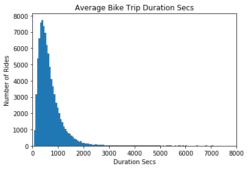

```python
#plotting the average trip duration

bin_edge = np.arange(0,df['duration_sec'].max()+100, 60)

plt.hist(data=df, x='duration_sec',bins=bin_edge)
plt.xlim(0,8000)
plt.title('Average Bike Trip Duration Secs')
plt.xlabel('Duration Secs')
plt.ylabel('Number of Rides');
```

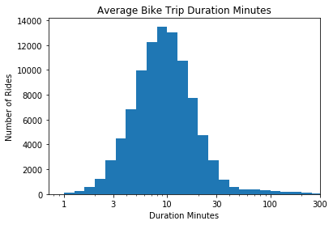

```python
# plotting the average trip duration in minutes and scale it

bin_edge = 10**np.arange(0,3+0.1,0.1)

ticks = [1,3,10,30,100,300,1000]
labels = ['{}'.format(v) for v in ticks]
df['duration_min'] = df['duration_sec']/60
plt.hist(data=df, x='duration_min',bins=bin_edge)
plt.xscale('log')
plt.xticks(ticks,labels);
plt.xlim(0,300)

plt.title('Average Bike Trip Duration Minutes')
plt.xlabel('Duration Minutes')
plt.ylabel('Number of Rides');
```

The average duration is a symmetric distribution after log-scale it. The majority of bike duration concentrades around 10 minutes.

### Discuss the distribution(s) of your variable(s) of interest. Were there any unusual points? Did you need to perform any transformations?

> The original distribution of duration variable is right skewed. There are some extremely large duration at the right tail. A log-scale on minutes distribution is needed to make distribution more symmetric.

### Of the features you investigated, were there any unusual distributions? Did you perform any operations on the data to tidy, adjust, or change the form of the data? If so, why did you do this?

> Right skewed. Log scale it. Duration based on minutes is easier for audience to accept.

## Duration in regarding to start time

```python
df.start_hr.value_counts().sort_values()
```

```
3        55
4       121
2       146
1       236
0       455
5       470
23      782
22     1317
6      1864
21     2019
20     2848
14     4106
11     4182
13     4579
19     4680
12     4783
10     4804
15     4853
7      5589
16     7200
18     8128
9      9002
17    11103
8     11480
Name: start_hr, dtype: int64
```

```python
df.query("start_hr==0").duration_min.mean()
```

```
27.965824175824153
```

```python
df_start_hr = df.groupby('start_hr').duration_min.sum()
xlabel = a.index.astype('str')
```

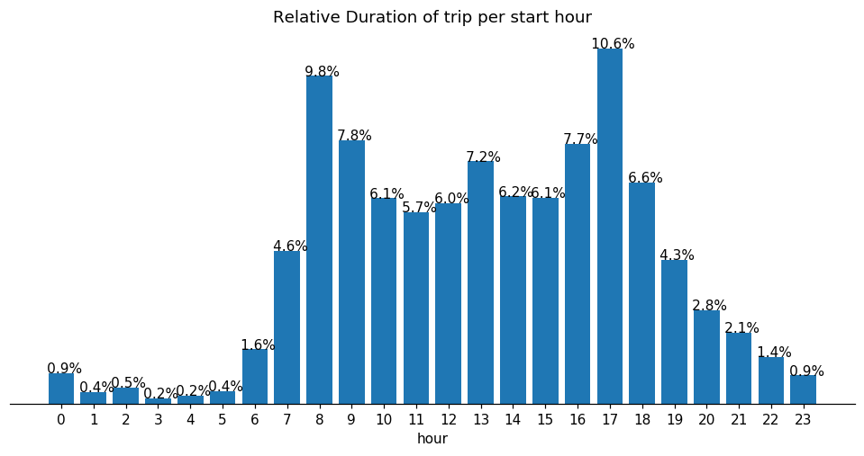

```python
fig, ax = plt.subplots(figsize = (11,5), dpi = 110)

plt.bar(xlabel, df_start_hr)
cur_axes = plt.gca()
cur_axes.axes.get_yaxis().set_visible(False)
sns.despine(fig, left = True)
plt.xlabel('hour')
plt.ylabel('Duration_mins')
plt.title('Relative Duration of trip per start hour')
for b in ax.patches:
    ax.annotate('{:10.1f}%'.format(b.get_height()/sum(df_start_hr)*100), (b.get_x()-1,b.get_height()))
```

### Talk about some of the relationships you observed in this part of the investigation. How did the feature(s) of interest vary with other features in the dataset?

> The relative duration bar chart above shows there are two peak time period at 0800 and 1700. It coincides with the fact people go out for work around 8 am and go back home around 5 pm.

### Did you observe any interesting relationships between the other features (not the main feature(s) of interest)?

> There is a dramtic downward pattern after 1700 and begins to increase at 0600.

## Multivariate Exploration

```python
df_three = df.groupby(['dayofweek','start_hr','bike_share_for_all_trip'], as_index=False).duration_min.sum()

df_three
```

|  | dayofweek | start_hr | bike_share_for_all_trip | duration_min |
| --- | --- | --- | --- | --- |
| 0 | 0 | 0 | No | 2052.200000 |
| 1 | 0 | 0 | Yes | 333.066667 |
| 2 | 0 | 1 | No | 848.983333 |
| 3 | 0 | 1 | Yes | 54.500000 |
| 4 | 0 | 2 | No | 721.466667 |
| ... | ... | ... | ... | ... |
| 331 | 6 | 21 | Yes | 857.833333 |
| 332 | 6 | 22 | No | 1007.916667 |
| 333 | 6 | 22 | Yes | 243.983333 |
| 334 | 6 | 23 | No | 611.533333 |
| 335 | 6 | 23 | Yes | 133.433333 |

336 rows × 4 columns

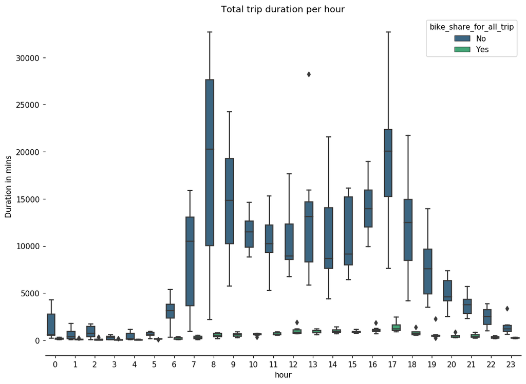

```python
fig, ax = plt.subplots(figsize = (12,7), dpi = 110)
sns.boxplot(x = "start_hr", y = "duration_min", data = df_three, palette = "viridis", hue = "bike_share_for_all_trip")
plt.tight_layout()
#cur_axes = plt.gca()
#cur_axes.axes.get_yaxis().set_visible(False)
sns.despine(fig, left = True)
plt.xlabel("hour")
plt.ylabel("Duration in mins")
plt.title("Total trip duration per hour")

ax.set(xticklabels=xlabel);

box = ax.get_position()
ax.set_position([box.x0, box.y0, box.width * 0.8, box.height])
```

### Talk about some of the relationships you observed in this part of the investigation. Were there features that strengthened each other in terms of looking at your feature(s) of interest?

> The majority of rides is not bike share. The duration of shared bike ride at each hour is really minimal.

### Were there any interesting or surprising interactions between features?

> The peak hours (at 0800 and 1700) are the most volitale during the week. The impact from day of week is different among different working hours.